# Next Word Prediction

Florian Dollak  
2018-08-21

This app is part of the capstone project of the Coursera Data Science Specialization as offered by the Johns Hopkins University.

The goal of this app is to predict the next word in a string based on some text input.

### The Data

In order to create a comprehensive language model, I've used 80% of the [HC Corpora](https://d396qusza40orc.cloudfront.net/dsscapstone/dataset/Coursera-SwiftKey.zip) dataset and also the full [OANC](http://www.anc.org/) corpus to get a good representation of American English as it is used on the internet and in everyday language.

| Filename | Filesize [MB] | Linecount | Wordcount |
| --- | --- | --- | --- |
| Blogs | 200.42 | 899288 | 37599515 |
| News | 159.36 | 2360148 | 30093410 |
| Twitter | 196.28 | 77259 | 2674536 |
| OANC | 92.26 | 1463146 | 14728941 |

Currently, the focus was exclusively on (American) English, but the general framework can be easily adapted to accommodate other languages as well.

### The Algorithm

Over the course of development I have implemented and evaluated various smoothing and discounting techniques to prepare the data properly for prediction. Among the implemented methods were:

- Absolute Discounting
- Good Turing Discounting
- Katz Backoff Smoothing
- (Modified) Kneser-Ney Smoothing
- Stupid BackOff

In the end I decided to increase the amount of training data and implement the Stupid Backoff method because the computational load is low and the loss in accuracy is negligible for large amounts of data compared to Modified-Kneser-Ney, which is considered one of the most efficient smoothing algorithms to date.

### The App

The overall design goal for [my app](https://floweffect.shinyapps.io/Next_Word_Prediction/) was to create a lightweight, fast and memory efficient app that is flexible enough to be displayed properly on a wide range of devices.

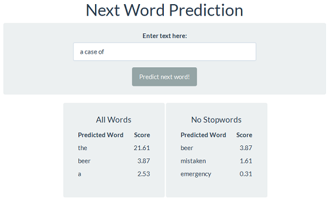

How it works:

1. Enter text into the textbox and press the button
2. The app shows the three most likely predictions with and without stopwords ranked by algorithm score

### Additional Information & Links

For reference, you can find:

- the app here https://floweffect.shinyapps.io/Next_Word_Prediction/
- my github page for the capstone project here https://github.com/FloWEffect/CCP
- and finally the link to this presentation http://rpubs.com/FloWEffect/Capstone

Last but not least I want to thank all my fellow students for their insight and feedback, the mentors for their time and effort and lastly the creators of this course. I've learned quite a few new things and was able to revisit some stuff I've already learned at some point in my life.